# Tugas Pertemuan 5

# Proses MA(2)

## Pembangkitan Data

```r
set.seed(75)
wn <- rnorm(300)
ma2 <- c(wn[1], wn[2])
for(i in 3:300){
   ma2[i] <- wn[i] + 0.4 * wn[i - 1] + 0.6 * wn[i - 2]
}
ma2
```

```
##   [1] -0.793094704  0.478825670 -1.718149678 -0.160658894  0.785553366
##   [6]  1.479701548  1.662104024  1.306687694 -0.786801202  0.207672979
##  [11] -0.928244876  1.198230241 -0.979053478  2.455514478  1.264787195
##  [16]  1.366351855  0.441023366  0.323058005 -0.416771769 -0.268272578
##  [21] -1.883309273 -0.512786990  0.049075597 -0.362944037 -1.494694961
##  [26] -1.520545270 -0.719448867 -0.534610600 -0.405625501 -0.178480451
##  [31] -1.062804940 -0.937080813 -0.928996087 -0.624027581 -0.291053963
##  [36]  0.310537655 -0.605277533 -0.406975820 -1.077438535  1.446976706
##  [41]  1.680494401  1.797358121  1.531854828  1.801523215  1.100358369
##  [46] -0.246177758 -0.544317796 -1.390938165 -0.258699410 -0.614152667
##  [51] -1.471020129 -1.357266031 -0.799763580 -1.454653847 -0.351094285
##  [56]  1.117313575  0.204272176 -0.830448367  0.214530423 -0.909429542
##  [61]  0.653782948 -0.937941829 -0.622651541 -0.226584820  0.217390038
##  [66]  0.679784322  1.371036849  1.592546107  0.887484590  1.229545719
##  [71]  0.367801128  0.027344340  0.197007296 -0.350547610  1.932039441
```

[output cut: 45 more lines]

```r
ma2 <- arima.sim(list(order=c(0, 0, 2), ma=c(0.4, 0.6)),
                 n=300)
ma2
```

```
## Time Series:
## Start = 1
## End = 300
## Frequency = 1
##   [1]  1.343828009  0.988957712  1.440746372  0.424391534 -0.727633034
##   [6]  0.551277239 -0.120431183  0.421828670 -2.506932069 -1.944802984
##  [11] -1.842227906 -0.471195516 -0.995492688  1.683380721 -1.136102188
##  [16]  1.822947505 -0.409032471  0.350468410 -0.469855037 -1.154325320
##  [21] -0.425973162 -0.545769273 -0.153450272  2.030965283  0.366983189
##  [26]  0.858500054 -0.982407879  0.566035560  0.571246661  1.454045455
##  [31]  1.848082305  0.633236192 -0.849041034 -0.846128386 -0.799819963
##  [36]  1.810466871 -0.691129336  1.261517874 -0.843333749  1.140241575
##  [41]  0.110070521  1.149363007  2.197437395  2.246780419  2.149618604
##  [46] -0.850696372  0.169900824 -0.298510332  1.876871569 -0.106019385
##  [51]  0.119145457 -2.077290546 -2.341891747 -1.563642567 -0.757621250
```

[output cut: 49 more lines]

## Visualisasi

### Plot Time Series

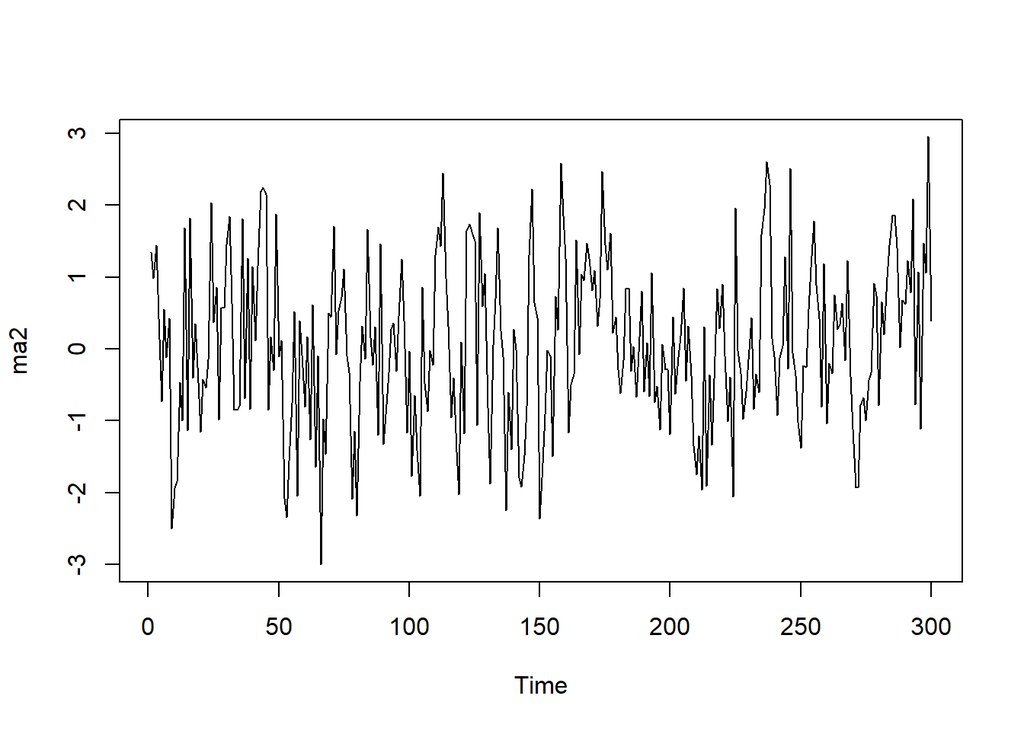

```r
ts.plot(ma2)
```

Berdasarkan plot time series, terlihat bahwa data MA(2) yang dibangkitkan stasioner dalam rataan.

### Plot ACF

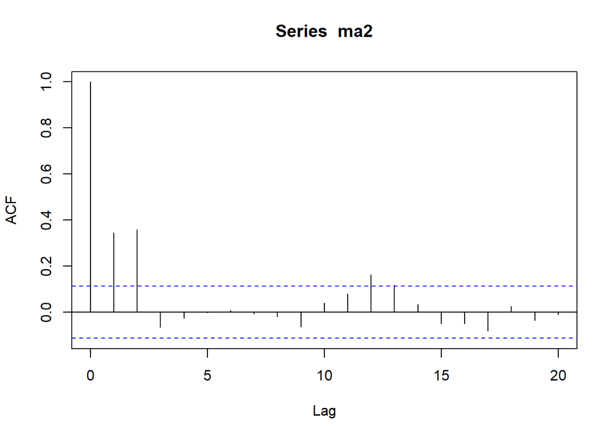

```r
acf(ma2,lag.max = 20)
```

Berdasarkan plot ACF tersebut, terlihat bahwa plot ACF *cuts off* di lag pertama dan kedua.

### Plot PACF

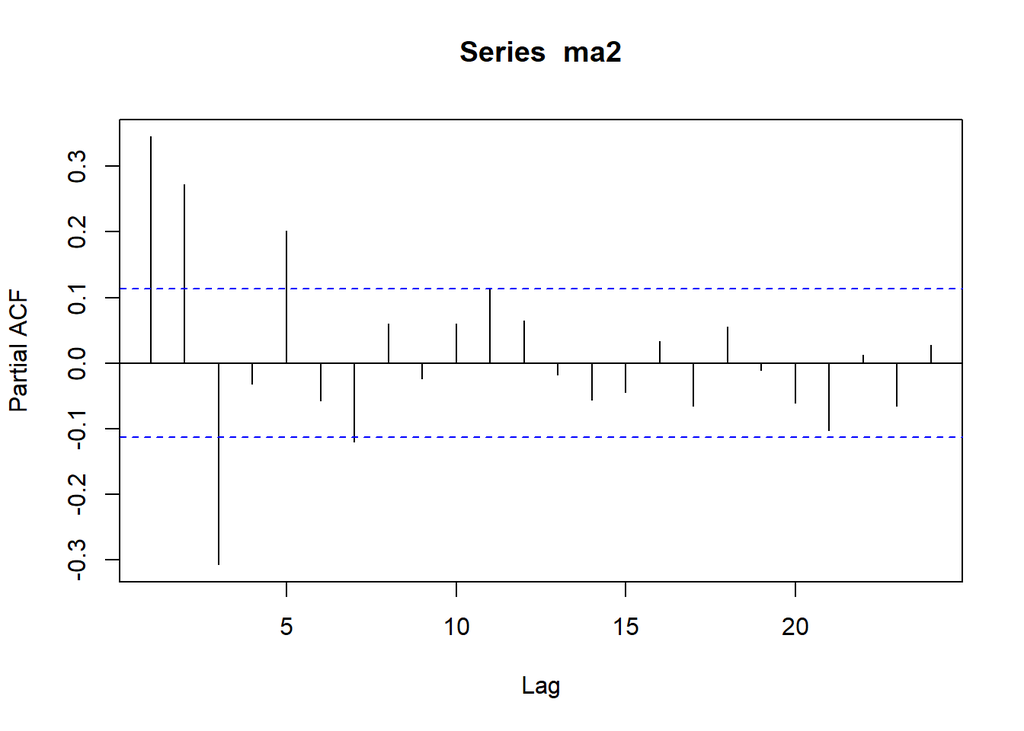

```r
pacf(ma2)
```

Berdasarkan plot PACF tersebut, terlihat bahwa plot PACF cenderung *tails off* dan membentuk gelombang sinus.

### Plot EACF

```r
TSA::eacf(ma2)
```

```
## AR/MA
##   0 1 2 3 4 5 6 7 8 9 10 11 12 13
## 0 x x o o o o o o o o o  x  o  o
## 1 x x x o o o o o o o o  o  o  o
## 2 x x x o o o o o o o o  o  o  o
## 3 o x x o o o o o o o o  o  o  o
## 4 x x x o o o o o o o o  o  o  o
## 5 x x x o o o o o o o o  o  o  o
## 6 x x o o o o o o o o o  o  o  o
## 7 x o x x o o o o x o o  o  o  o
```

Berdasarkan pola segitiga nol pada plot EACF, terlihat bahwa segitiga nol berada pada ordo AR(0) dan ordo MA(2)

### Scatterplot antar Lag

#### Korelasi antara $Y_t$ dengan $Y_{t-1}$

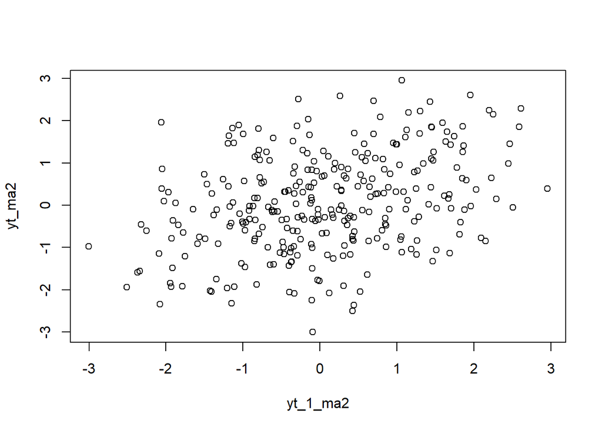

```r
yt_ma2 <- ma2[-1]
yt_1_ma2 <- ma2[-300]

plot(y=yt_ma2,
     x=yt_1_ma2)
```

Berdasarkan scatterplot tersebut, terlihat bahwa terdapat hubungan positif antara $Y_t$ dengan $Y_{t-1}$. Hal ini sesuai dengan teori yang ada

```r
cor(yt_ma2, yt_1_ma2)
```

```
## [1] 0.3457703
```

Korelasi antara $Y_t$ dengan $Y_{t-1}$ dari hasil simulasi mendekati perhitungan teoritis yaitu

$$\rho_1 =
\frac{\theta_1 + \theta_1 \theta_2}{1 + \theta_1^2 + \theta_2^2} =
\frac{0.4 + 0.4 \cdot 0.6}{1 + 0.4^2 + 0.6^2} =
0.421$$

#### Korelasi antara $Y_t$ dengan $Y_{t-2}$

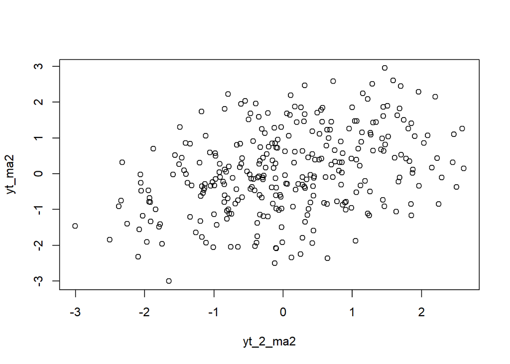

```r
yt_ma2 <- ma2[-c(1, 2)]
yt_2_ma2 <- ma2[-c(299, 300)]

plot(y=yt_ma2,
     x=yt_2_ma2)
```

```r
cor(yt_ma2, yt_2_ma2)
```

```
## [1] 0.3641088
```

#### Korelasi antara $Y_t$ dengan $Y_{t-3}$

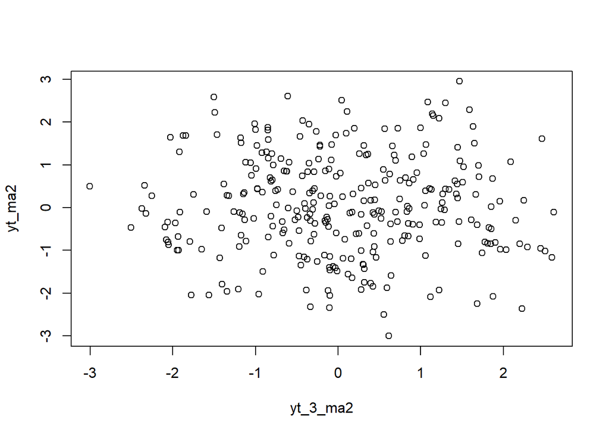

```r
yt_ma2 <- ma2[-c(1, 2, 3)]
yt_3_ma2 <- ma2[-c(288, 299, 300)]

plot(y=yt_ma2,
     x=yt_3_ma2)
```

Berdasarkan scatterplot tersebut, terlihat bahwa cenderung tidak terdapat hubungan antara $Y_t$ dengan $Y_{t-3}$.

```r
cor(yt_ma2, yt_3_ma2)
```

```
## [1] -0.02964149
```

# Proses AR(2)

## Pembangkitan Data

```r
set.seed(75)
wn <- rnorm(300)
ar2 <- 1:300
for (i in 3:300) {
  ar2[i] <- wn[i] + 0.5 * ar2[i-1] + 0.2 * ar2[i-2]
}
ar2
```

```
##   [1]  1.000000000  2.000000000 -0.233823124  0.408663392  1.753184330
##   [6]  1.724434516  1.611143924  1.838164836 -0.059546268  0.653252218
##  [11]  0.040829508  1.269614947 -0.619167594  2.233580208  2.099331956
##  [16]  1.046639116  0.900281254  1.269534075  0.179768086 -0.036499014
##  [21] -1.332456093 -0.418076835  0.281461677 -0.761895699 -1.945940794
##  [26] -1.505973992 -0.736603071 -1.137961094 -1.177884009 -0.529302679
##  [31] -1.400975991 -1.555469131 -1.146828901 -1.023503843 -0.923233956
##  [36] -0.199536251 -0.967135295 -0.937431463 -1.164366472  1.126570589
##  [41]  1.553744563  1.172467425  1.626725505  2.455313685  1.652531605
##  [46]  0.186864449  0.272088589 -0.478502543 -0.091655099 -0.401800270
##  [51] -1.642049472 -1.533360167 -0.788372417 -1.899013887 -1.163043990
##  [56]  0.897227215 -0.289626271 -1.708694820  0.302967258 -0.539784570
##  [61] -0.144848145 -0.934385550 -0.855882533 -0.245112406 -0.008392983
##  [66]  0.290605876  1.205927415  1.622414851  0.917963667  1.489984238
##  [71]  1.094435752  0.382307043  0.692700500  0.236944725  2.093802780
```

[output cut: 45 more lines]

```r
ar2 <- arima.sim(list(order=c(2, 0, 0), ar=c(0.7, 0.2)),
                 n=300)
ar2
```

```
## Time Series:
## Start = 1
## End = 300
## Frequency = 1
##   [1] -1.42898853 -1.02187017  0.09869953  0.49090944 -0.64753984 -0.65889592
##   [7] -1.95426078 -1.91950506 -3.07304971 -2.20906230 -1.17621362 -1.99092972
##  [13] -0.26442193 -0.53404458 -1.48539921 -0.45061111 -1.45107305  0.27769846
##  [19] -1.46954477 -2.17005044 -0.84410757 -0.41636404 -0.92325813 -1.21707429
##  [25] -0.10400250  0.84951811 -0.05619281 -1.48831037 -0.05962405 -1.53880017
##  [31] -1.85559113 -1.98943412 -3.19768940 -0.97384060 -1.60944725 -3.06927394
##  [37] -1.62312166 -1.26214380 -0.61380719  0.48607585  0.82439777  2.17971212
##  [43]  1.70920324  1.04152260  0.33713941  0.68755571 -0.53659790 -1.97625265
##  [49] -0.04589396 -1.14294320  0.25737695  1.69665602  1.53394364  1.75657361
##  [55]  0.16575867  2.71017923  2.44505352  1.74988553  0.78655499 -0.30027038
##  [61]  1.04053248  1.64699306  1.99359161  1.13440393  0.94403138 -0.91172900
```

[output cut: 39 more lines]

## Visualisasi

### Plot Time Series

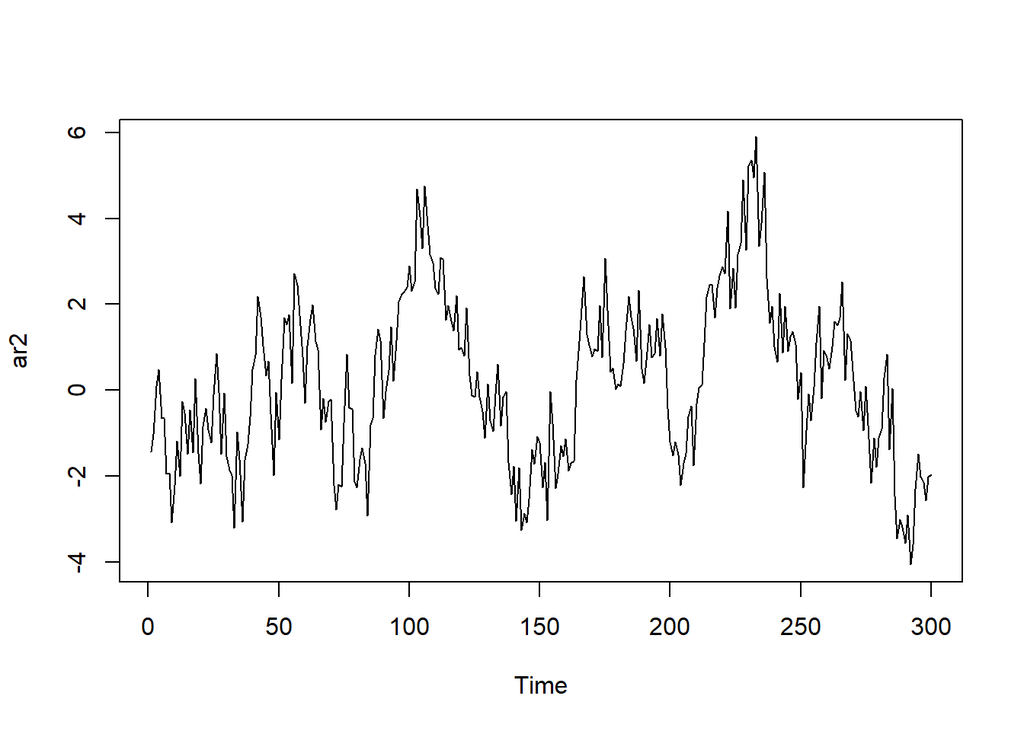

```r
ts.plot(ar2)
```

Berdasarkan plot time series, terlihat bahwa data AR(2) yang dibangkitkan stasioner dalam rataan.

### Plot ACF

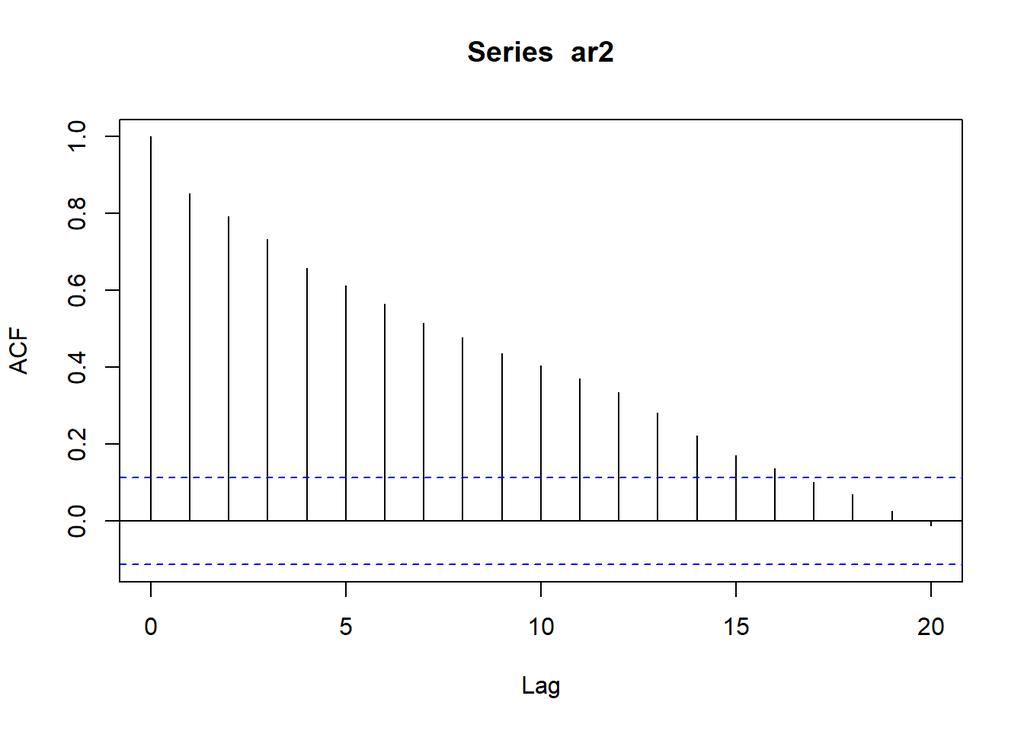

```r
acf(ar2,lag.max = 20)
```

### Plot PACF

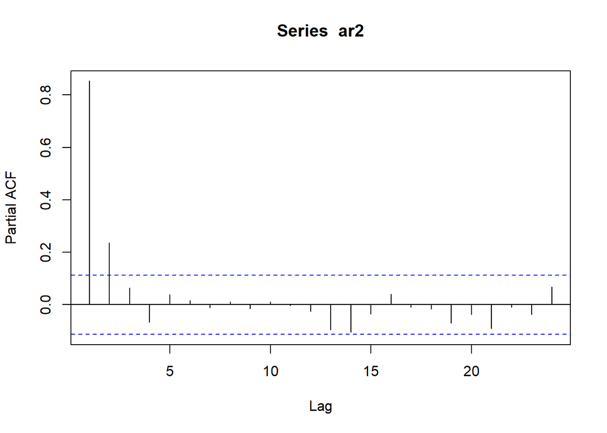

```r
pacf(ar2)
```

Berdasarkan plot PACF tersebut, terlihat bahwa plot PACF *cuts off* pada lag pertama dan kedua, sejalan dengan teori yang ada.

### Plot EACF

```r
TSA::eacf(ar2)
```

```
## AR/MA
##   0 1 2 3 4 5 6 7 8 9 10 11 12 13
## 0 x x x x x x x x x x x  x  x  x
## 1 x o o o o o o o o o o  o  o  o
## 2 x o o o o o o o o o o  o  o  o
## 3 x o o o o o o o o o o  o  o  o
## 4 x x x o o o o o o o o  o  o  o
## 5 x o x o o o o o o o o  o  o  o
## 6 x o x x o o o o o o o  o  o  o
## 7 o x x x o o o o o o o  o  o  o
```

Berdasarkan pola segitiga nol pada plot EACF, terlihat bahwa segitiga nol berada pada ordo AR(1) dan ordo MA(1)

### Scatterplot antar Lag

#### Korelasi antara $Y_t$ dengan $Y_{t-1}$

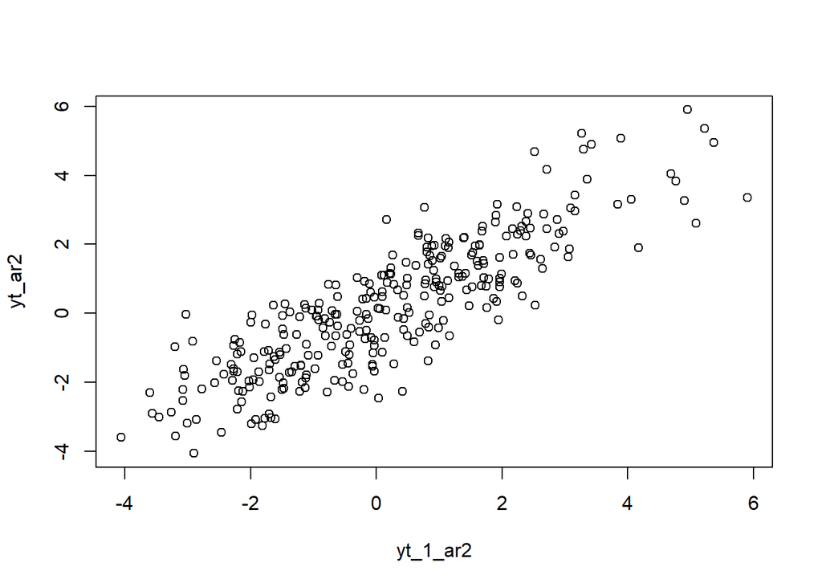

```r
yt_ar2 <- ar2[-1]
yt_1_ar2 <- ar2[-300]

plot(y=yt_ar2,
     x=yt_1_ar2)
```

Berdasarkan scatterplot tersebut, terlihat bahwa terdapat hubungan positif antara $Y_t$ dengan $Y_{t-1}$. Hal ini sesuai dengan teori yang ada

```r
cor(yt_ar2, yt_1_ar2)
```

```
## [1] 0.8559376
```

Korelasi antara $Y_t$ dengan $Y_{t-1}$ dari hasil simulasi mendekati perhitungan teoritis yaitu

$$\rho_1 =
\frac{\phi_1}{1 - \phi_2} =
\frac{0.7}{1 - 0.2} =
0.875$$

#### Korelasi antara $Y_t$ dengan $Y_{t-2}$

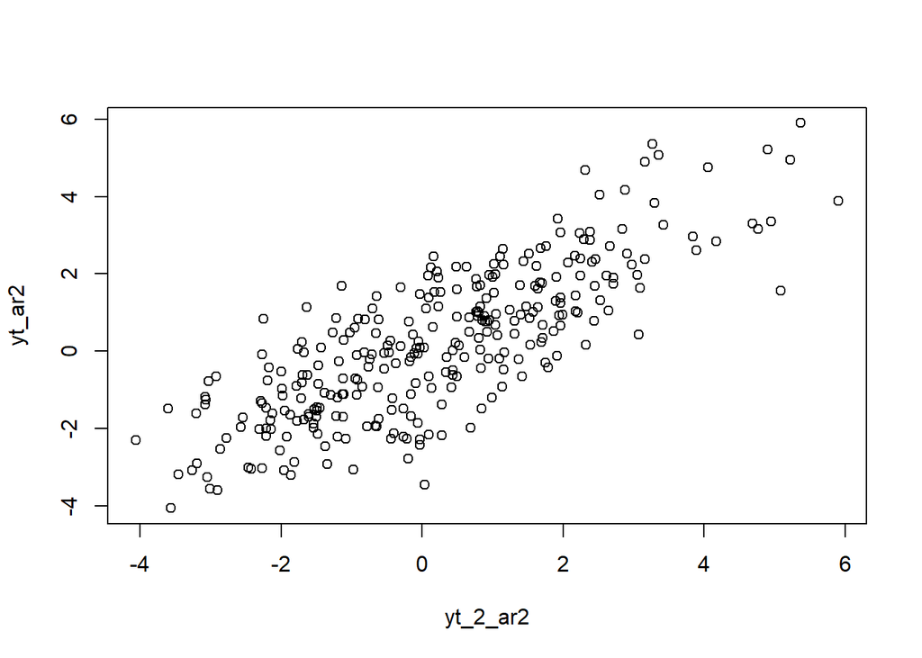

```r
yt_ar2 <- ar2[-c(1, 2)]
yt_2_ar2 <- ar2[-c(299, 300)]

plot(y=yt_ar2,
     x=yt_2_ar2)
```

Berdasarkan scatterplot tersebut, terlihat bahwa terdapat hubungan positif antara $Y_t$ dengan $Y_{t-1}$. Hal ini sesuai dengan teori yang ada

```r
cor(yt_ar2, yt_2_ar2)
```

```
## [1] 0.7970122
```

Korelasi antara $Y_t$ dengan $Y_{t-2}$ dari hasil simulasi mendekati perhitungan teoritis yaitu

$$\rho_2 =
\phi_1 \rho_1 + \phi_2 \rho_0 =
0.7 \cdot 0.875 + 0.2 \cdot 1 =
0.8125$$

#### Korelasi antara $Y_t$ dengan $Y_{t-3}$

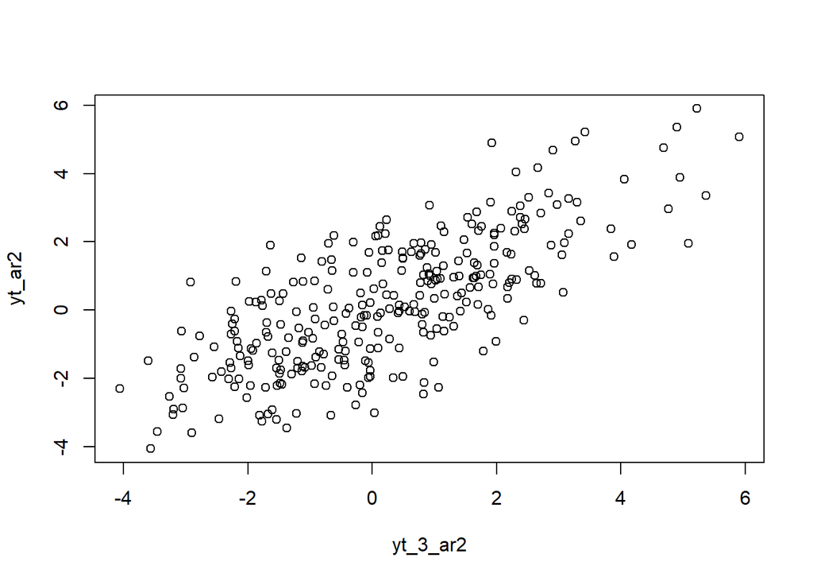

```r
yt_ar2 <- ar2[-c(1, 2, 3)]
yt_3_ar2 <- ar2[-c(288, 299, 300)]

plot(y=yt_ar2,
     x=yt_3_ar2)
```

```r
cor(yt_ar2, yt_3_ar2)
```

```
## [1] 0.7417183
```

Korelasi antara $Y_t$ dengan $Y_{t-1}$ dari hasil simulasi mendekati perhitungan teoritis yaitu

$$\rho_3 =
\phi_1 \rho_2 + \phi_2 \rho_1 =
0.7 \cdot 0.8125 + 0.2 \cdot 0.875 =
0.74375$$

# Proses ARMA(2, 2)

## Pembangkitan Data

```r
arma.sim <- function(n, ma.coef, ar.coef){
  ma.num <- length(ma.coef)
  ar.num <- length(ar.coef)
  stopifnot(ma.num < n & ar.num < n)

  wn <- rnorm(n, sd = 0.5)
  init <- max(ma.num, ar.num)

  arma <- wn[1:init]
  for(i in {init+1}:n){
   ma.start <- i - ma.num
   ma.end <- i-1

   ar.start <- i - ar.num
   ar.end <- i-1

   arma[i] <- sum(ar.coef * arma[ar.start:ar.end]) + sum(ma.coef * wn[ma.start:ma.end])  + wn[i]
   }
  return(arma)
}

arma22 <- arma.sim(300, c(0.4, 0.6), c(0.5, 0.2))
arma22
```

```
##   [1]  0.106323919  0.436403537  0.116309415 -0.109568533 -2.035931106
##   [6] -2.534292774 -2.443056161 -1.324219286 -1.363867212 -1.240589433
##  [11] -1.587554722 -1.198705822 -1.143914167 -1.140930489 -1.288198500
##  [16] -1.932970447 -1.295432679 -1.683732523 -1.204992409 -1.550957754
##  [21] -1.093596807 -0.960923550 -0.517962688 -0.810339515 -0.587941922
##  [26] -0.814154861  0.131392935  1.171830055  0.775412863  0.060211237
##  [31] -0.281510437 -0.567710952 -0.630711480 -0.752458951 -0.853438405
##  [36] -0.646036549 -0.814859541 -0.724978785 -1.082960552 -1.354019361
##  [41] -0.626587023 -1.019059567 -0.218172870 -0.187465394 -0.143789712
##  [46] -0.603563521 -0.752040872 -2.249057190 -1.896513094 -2.440581576
##  [51] -2.368604267 -1.831240430 -1.383653017 -1.322779050 -1.056193791
##  [56] -0.387977129 -0.483662494 -0.282295748 -1.153953296 -0.616470980
##  [61] -0.243549408  0.561772926  0.341581634  0.796035602  0.270379036
##  [66]  0.666095445 -0.009151105  0.135697449 -0.765920784 -1.171819906
##  [71] -1.413213259 -1.068573383 -1.348183239 -0.643748509 -0.480960964
```

[output cut: 45 more lines]

```r
arma22 <- arima.sim(list(order=c(2, 0, 2), ma=c(0.4, 0.6), ar=c(0.5, 0.2)),
                 n=300)
arma22
```

```
## Time Series:
## Start = 1
## End = 300
## Frequency = 1
##   [1]  0.033918197  0.537622509  2.281980588  2.843585535  3.819596914
##   [6]  2.960764399  2.481754153 -2.198219237 -2.300493359 -6.126820434
##  [11] -2.648436216 -3.682122771 -1.970210884 -1.126468258 -1.758386717
##  [16] -0.827563500  0.404740137  0.085657991  1.412388121  0.194476678
##  [21] -0.432364199 -1.656309786  0.004369389 -1.197622038  0.046855458
##  [26] -1.417315857  0.241028437  0.160092523  2.561094561  2.682196929
##  [31]  3.398114255  2.379896805  2.037355325  0.797268437 -0.640673777
##  [36]  0.601056495  0.336080579  0.751943911  1.441617146  0.164140503
##  [41]  2.732136635  0.395096938  0.962260612  0.266036213  0.146905696
##  [46]  0.676905154  1.854670702  3.114948689  2.512546507  2.106769452
##  [51]  1.075543190  1.597450541  2.093586249  2.973933817  2.285476320
```

[output cut: 49 more lines]

## Visualisasi

### Plot Time Series

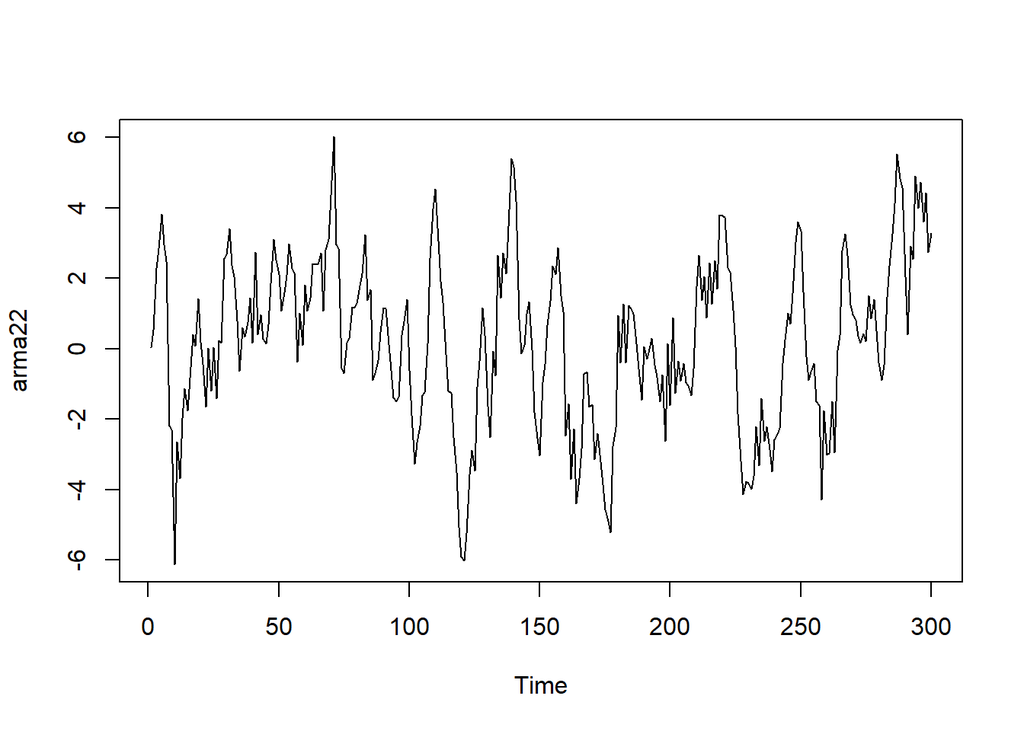

```r
ts.plot(arma22)
```

Berdasarkan plot time series, terlihat bahwa data ARMA(2, 2) yang dibangkitkan stasioner dalam rataan.

### Plot ACF

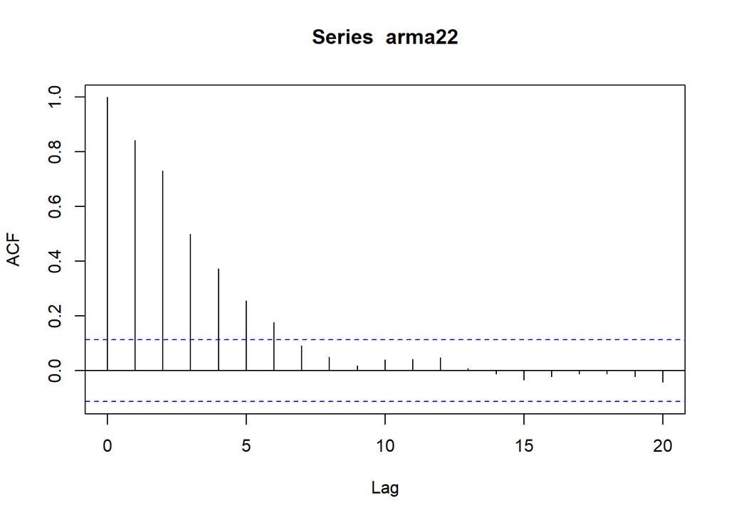

```r
acf(arma22, lag.max = 20)
```

Berdasarkan plot ACF tersebut, terlihat bahwa model ARMA(2, 2) hasil simulasi memiliki plot ACF yang *tails off*, sesuai dengan teori yang ada.

### Plot PACF

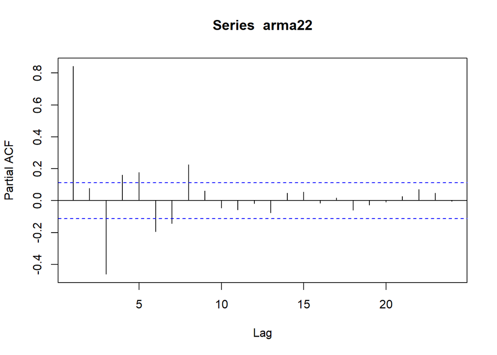

```r
pacf(arma22)
```

Berdasarkan plot PACF tersebut, terlihat bahwa model ARMA(2, 2) hasil simulasi memiliki plot PACF yang *tails off*, sesuai dengan teori.

### Plot EACF

```r
TSA::eacf(arma22)
```

```
## AR/MA
##   0 1 2 3 4 5 6 7 8 9 10 11 12 13
## 0 x x x x x x o o o o o  o  o  o
## 1 o x x o o o o o o o o  o  o  o
## 2 x x o o o o o o x o o  o  o  o
## 3 x x x o x o o o x o o  o  o  o
## 4 x x o x x o o o o o o  o  o  o
## 5 x x o x x o o o o o o  o  o  o
## 6 x x o o x x o o o o o  o  o  o
## 7 x x o o x o o o o o o  o  o  o
```

Berdasarkan pola segitiga nol pada plot EACF, terlihat bahwa segitiga nol berada pada ordo AR(2) dan ordo MA(9)

### Scatterplot antar Lag

#### Korelasi antara $Y_t$ dengan $Y_{t-1}$

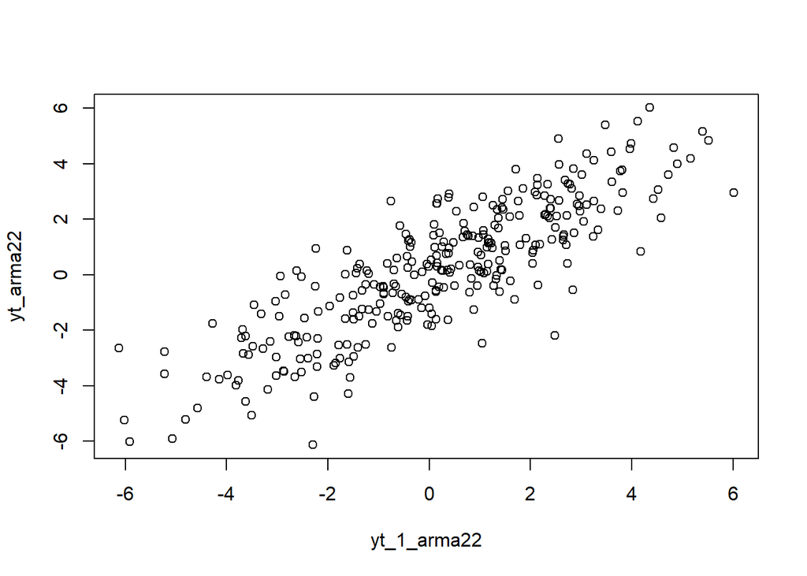

```r
yt_arma22 <- arma22[-1]
yt_1_arma22 <- arma22[-300]

plot(y=yt_arma22,
     x=yt_1_arma22)
```

Berdasarkan scatterplot tersebut, terlihat bahwa terdapat hubungan positif antara $Y_t$ dengan $Y_{t-1}$. Hal ini sesuai dengan teori yang ada

```r
cor(yt_arma22, yt_1_arma22)
```

```
## [1] 0.844391
```

#### Korelasi antara $Y_t$ dengan $Y_{t-2}$

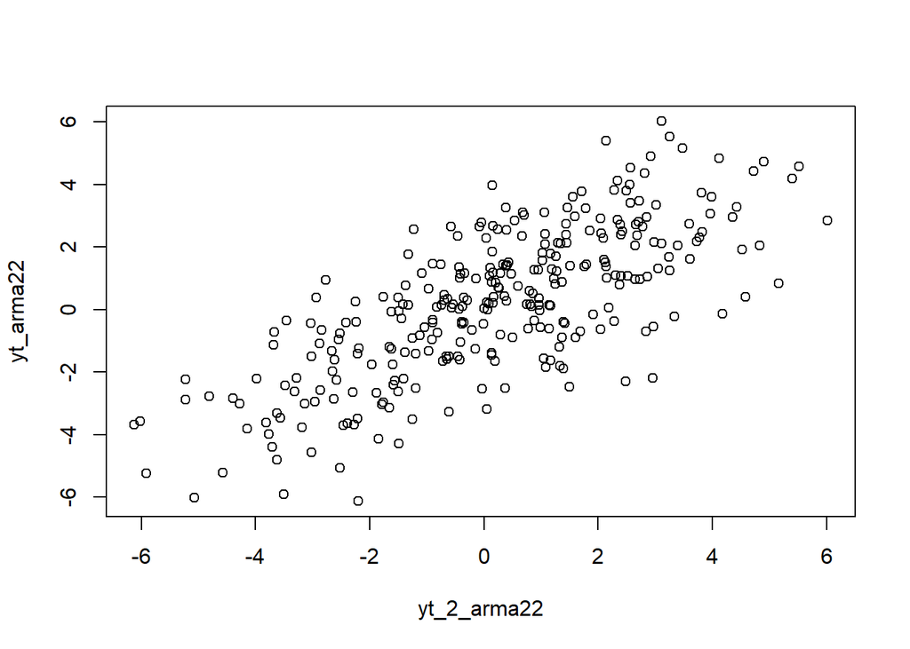

```r
yt_arma22 <- arma22[-c(1, 2)]
yt_2_arma22 <- arma22[-c(299, 300)]

plot(y=yt_arma22,
     x=yt_2_arma22)
```

Berdasarkan scatterplot tersebut, terlihat bahwa terdapat hubungan positif antara $Y_t$ dengan $Y_{t-1}$. Hal ini sesuai dengan teori yang ada

```r
cor(yt_arma22, yt_2_arma22)
```

```
## [1] 0.7351048
```

#### Korelasi antara $Y_t$ dengan $Y_{t-3}$

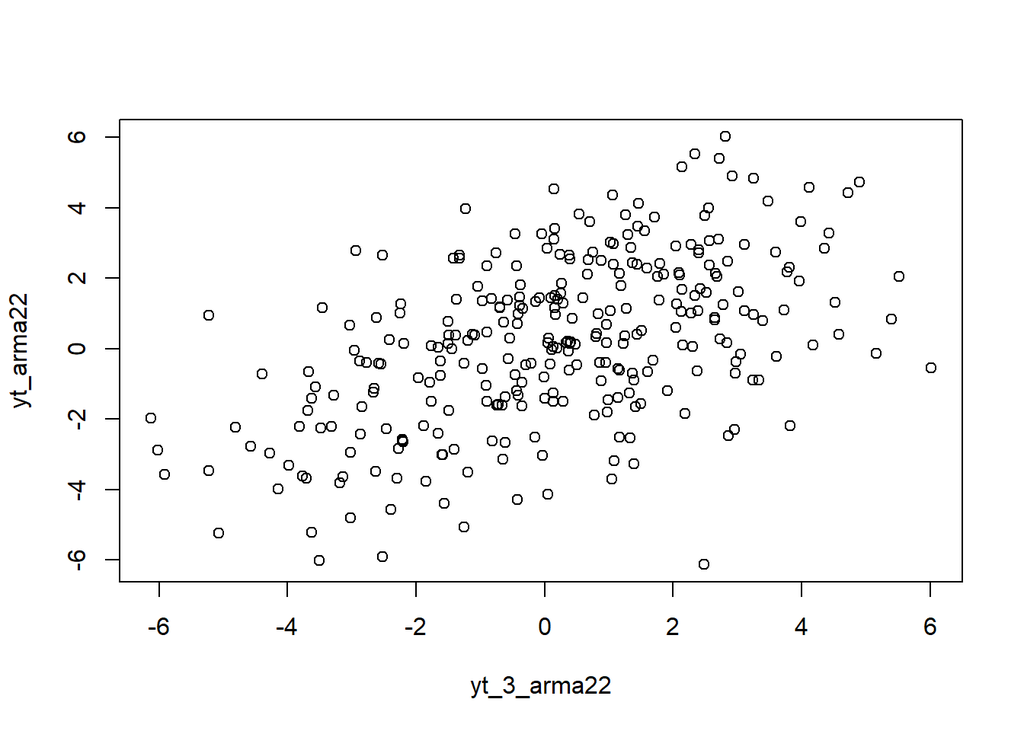

```r
yt_arma22 <- arma22[-c(1, 2, 3)]
yt_3_arma22 <- arma22[-c(288, 299, 300)]

plot(y=yt_arma22,
     x=yt_3_arma22)
```

```r
cor(yt_arma22, yt_3_arma22)
```

```
## [1] 0.5125917
```